# Questions

Kianté Fernandez

9/1/2020

** Q: can you confirm: when you fit the subject-level models to get the betas, did you estimate them in two separate models, or in one model?**

The subject level models are estimated each with the following formula:

glm(treatment ~ risk.c*gain.c, data = x, family = binomial(link = "logit")

For each subject, I center the risk and gain variables denoted here with “.c” Also note that I include the interaction between the two within the model specification.

However. I think I found an issue that does slightly change the betas; mean centering by total sample, rather than by subject

Something principled we can do is exclude subjects with variance inflation factors above some threshold, this would remove subjects from the analysis whose solution is potentially unstable due to the relationship between the risk and gain (i.e. collinearity).

```r
options(scipen=999)

load("clean_task_data.2020.27.12.RData")

Neuroethics_Judgement %>%
dplyr::select(user_id,risk,gain,condition, experimental_treatment_selected, Yes, No,
              age, sex, Income, education, race_ethnicity, Optimize,
               republican, democrat, independent, conservative, liberal, Political_Party) %>%
  group_by(user_id) %>% #group by user id
  mutate(risk.c = scale(risk, scale = F)) %>% #mean center variables
  mutate(gain.c = scale(gain, scale = F)) %>%
  mutate(treatment = ifelse(experimental_treatment_selected == "Yes to treatment", 1, 0))  -> logit.data

m.logit <- by(logit.data, logit.data$user_id, function(x) glm(treatment ~ risk.c*gain.c, data = x, family = binomial(link = "logit")))
#here is the code that I use to get the subjects


##extract subject betas
n = nrow(logit.data)/75
user_id <- names(m.logit)
betas <- list()
colin <- list()

for (i in 1:n){
dat = m.logit[[i]]$coefficients
  betas[[i]] = dat
}
subjectModels <- do.call(rbind, betas)
colnames(subjectModels) <-  c('Intercept', 'Risk_Beta', 'Gain_Beta', 'Interaction')
subjectModels <- cbind.data.frame(user_id, subjectModels)

#check the variance inflation factors
for (i in user_id){
vif <- car::vif(m.logit[[i]])
colin[[i]] <- vif
}

subjectcolin <- as.data.frame(do.call(rbind, colin))
subjectcolin <- tibble::rownames_to_column(subjectcolin, "user_id")

#remove subject if they have vif for risk or gain above 4
subjectcolin %>%
  filter(!risk.c > 4) %>%
  filter(!gain.c > 4) -> index


#merge the subject models extracted above and the index
subjectModels <- merge(subjectModels, index, "user_id")

#create data that only contains subjects after VIF data exculsion
data <- merge(logit.data, subjectModels, "user_id")
data %>%
   mutate(conservatismFactor = republican + conservative - democrat - liberal) %>%
   mutate(inverse.risk = -Risk_Beta) %>%
   dplyr::select(c("user_id","condition", "age", "Income", "education", "Risk_Beta", "Gain_Beta", "conservatismFactor", "inverse.risk")) %>%
  distinct() %>%
  mutate(CogMotor = ifelse(condition == "Motor Function", "Motor", "Cognitive")) -> data

data$guaussian.risk <- LambertW::Gaussianize(data$Risk_Beta)
data$guaussian.gain <- LambertW::Gaussianize(data$Gain_Beta)
data$Agecat   <-cut(data$age, c(18,24,49,75))
data$Incomecat<-cut(data$Income, c(0, 25000,50000,75000, 200000))
#if we filter by 320
#if we add another filter where we check cell counts 296 add code below:
#filter(!Yes < 10) %>%
#filter(!No < 10) %>%
```

Note we lose 24 subjects that have large VIF and this does not fix our issue of some subjects have the opposite beta values than we would expect.

if we take the inverse of risk and look at it compared to gain they do not look too different from one another, though the distribution as a whole are more spread relative to what we saw before the VIF exlusions.

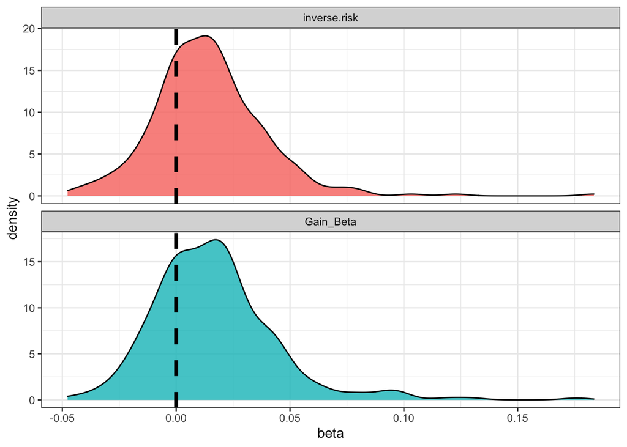

```r
data %>%
  dplyr::select(user_id, inverse.risk, Gain_Beta) %>%
  melt(id = c("user_id"), variable.name = "type", value.name = "beta") %>%
  ggplot(aes(beta, fill=type)) + geom_density(alpha = .8) +
  theme_bw()+
  theme(legend.position="none") +
  facet_wrap(~ type, scale = "free_y", nrow = 2) +
  geom_vline(xintercept = 0, linetype="dashed", size=1.5)
```

** Is it the case that in all subjects, they only made judgments about one cognitive function?** Yes, subjects only made judgments in a one cognitive function.

So just to show again: testing for the effect of condition on risk and gain

```r
data %>%
  dplyr::select(user_id, condition, CogMotor, guaussian.risk, guaussian.gain, age, Income, education, conservatismFactor) -> test

aov.risk <- stats::oneway.test(guaussian.risk ~ condition, data = test, var.equal= F)
aov.gain <- stats::oneway.test(guaussian.gain ~ condition, data = test, var.equal= F)

tab <- map_df(list(aov.risk,aov.gain), tidy)
```

```
## Multiple parameters; naming those columns num.df, denom.df
## Multiple parameters; naming those columns num.df, denom.df
```

```r
knitr::kable(tab[c("num.df", "den.df", "statistic", "p.value", "method")], caption = "condition tests")
```

condition tests

| num.df | den.df | statistic | p.value | method |
| --- | --- | --- | --- | --- |
| 6 | 136.0799 | 1.065242 | 0.3865273 | One-way analysis of means (not assuming equal variances) |
| 6 | 136.0646 | 1.129038 | 0.3487660 | One-way analysis of means (not assuming equal variances) |

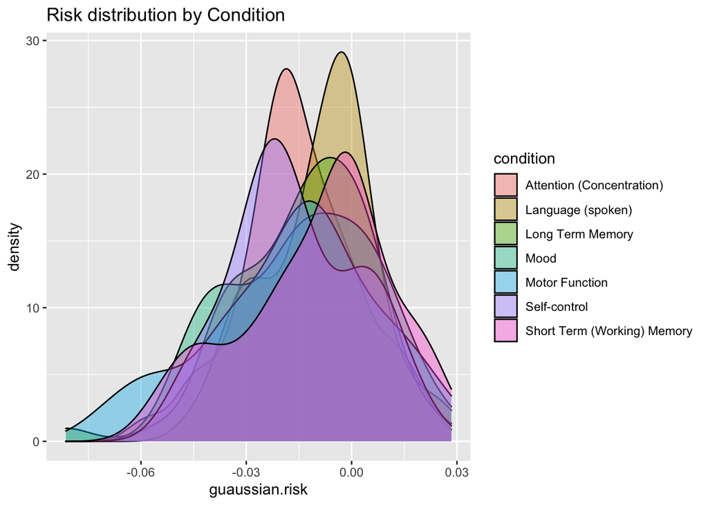

```r
ggplot(test,
       aes(x = guaussian.risk,
           fill = condition)) +
  geom_density(alpha = 0.4) +
  labs(title = "Risk distribution by Condition")
```

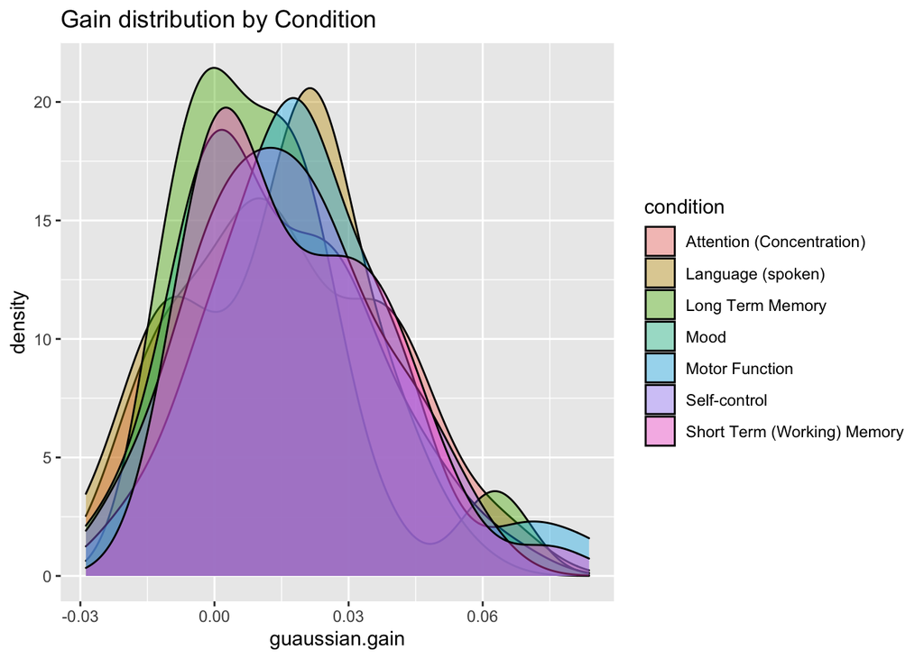

```r
ggplot(test,
       aes(x = guaussian.gain,
           fill = condition)) +
  geom_density(alpha = 0.4) +
  labs(title = "Gain distribution by Condition")
```

**q about the motor condition**

```r
t1 <- t.test(guaussian.risk ~ CogMotor, test, var.equal=TRUE)
t2 <- t.test(guaussian.gain ~ CogMotor, test, var.equal=TRUE)
tab <- map_df(list(t1,t2), tidy)

knitr::kable(tab[c("estimate", "statistic", "p.value", "parameter", "conf.low",
"conf.high", "method")], caption = "Cog-Motor tests")
```

Cog-Motor tests

| estimate | statistic | p.value | parameter | conf.low | conf.high | method |
| --- | --- | --- | --- | --- | --- | --- |
| 0.0038117 | 1.232131 | 0.2188103 | 318 | -0.0022748 | 0.0098982 | Two Sample t-test |
| -0.0064035 | -1.938320 | 0.0534690 | 318 | -0.0129032 | 0.0000962 | Two Sample t-test |

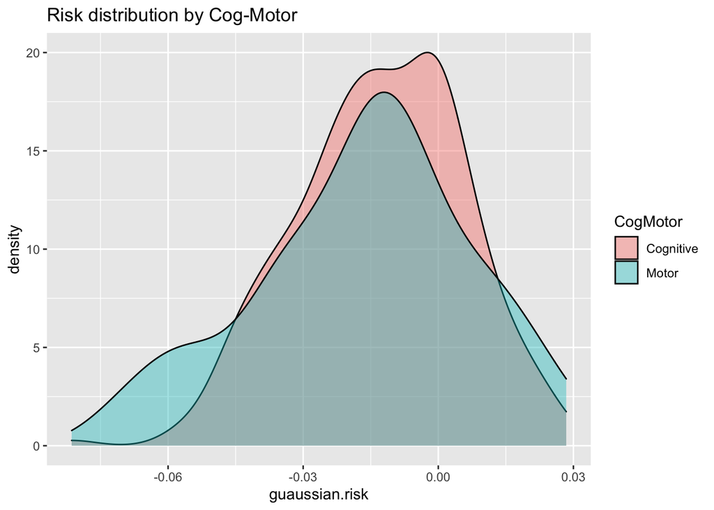

```r
ggplot(test,
       aes(x = guaussian.risk,
           fill = CogMotor)) +
  geom_density(alpha = 0.4) +
  labs(title = "Risk distribution by Cog-Motor")
```

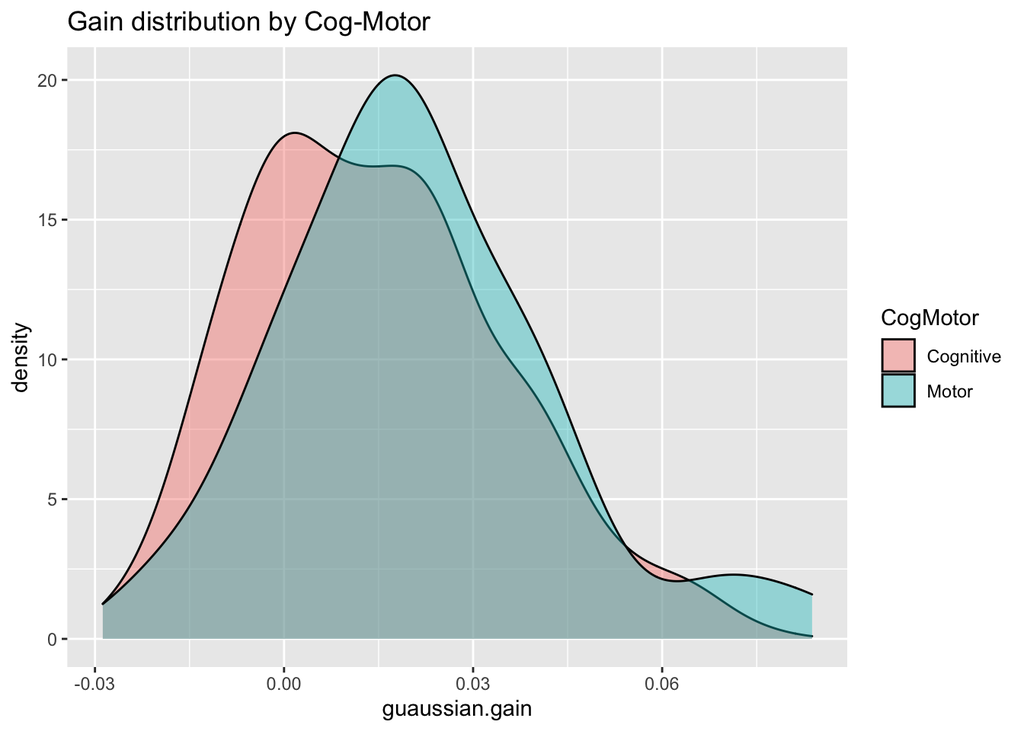

```r
ggplot(test,
       aes(x = guaussian.gain,
           fill = CogMotor)) +
  geom_density(alpha = 0.4) +
  labs(title = "Gain distribution by Cog-Motor")
```

Here is a t test between cogntive and motor domains for risk and gain. Here we see for gain, a larger gain beta for the motor. So what I could take from this is that in terms of gain, people weight the pros for motor more heaivly than that of cogntive domains. Something I think we could become more sensitive to if we test for this directly. Not sure if it matters here, but I know that the amount of observations in each group could be having an effect. Where because we alot of data for cogntive that variance is lower, and in contrast, motor variance is higher due to low sample amount.

**In my R01 aims, I'm predicting that "more affluent, educated, liberal, individualist, and younger individuals will be less risk-averse and more benefit-driven." Is this true in our data?**

Note we do not have data of 'individualist' since we choose not to include that measure.

Below the tables output are each of the linear regression models in order followed by a multivariate model for both risk and gain

```r
#Recode the variables for the model
data %>%
  dplyr::select(user_id, condition, guaussian.risk, guaussian.gain, Risk_Beta, Gain_Beta, Agecat, Incomecat, education, conservatismFactor) %>%
  mutate(education_recode = fct_recode(education,
  HighSchool = "less than high school",
  HighSchool = "high school degree",
  Undergraduate = "bachelor",
  Postgraduate = "masters",
  Postgraduate = "Doctoral/Professional"
)) %>%
  mutate(age_recode = fct_recode(Agecat,
  "18-24" = "(18,24]",
  "25-49" = "(24,49]",
  "50-75" = "(49,75]"
)) %>%
  mutate(income_recode = fct_recode(Incomecat,
  "< 25,000" = "(0,2.5e+04]",
  "25,000-50,000" = "(2.5e+04,5e+04]",
  "50,000-75,000"= "(5e+04,7.5e+04]",
  "> 75,000" = "(7.5e+04,2e+05]"
)) %>%
  mutate(educationSUM = C(education_recode, sum)) %>% #then we sum code for the models
  mutate(ageSUM = C(age_recode, sum)) %>%
  mutate(incomeSUM = C(income_recode, sum)) -> test

#predicting individual differences in risk and gain
lm.1 <- lm(guaussian.risk ~ageSUM, test)
lm.2 <- lm(guaussian.risk ~incomeSUM, test)
lm.3 <- lm(guaussian.risk ~educationSUM, test)
lm.4 <- lm(guaussian.risk ~conservatismFactor, test)

lm.multi.1 <- lm(guaussian.risk ~ ageSUM + incomeSUM + educationSUM + conservatismFactor, test)

tab <- map_df(list(lm.1,lm.2,lm.3,lm.4, lm.multi.1), tidy)
#%>% filter(!term == "(Intercept)")
knitr::kable(tab[c("term", "estimate", "std.error", "statistic", "p.value")], caption = "risk models")
```

risk models

| term | estimate | std.error | statistic | p.value |
| --- | --- | --- | --- | --- |
| (Intercept) | -0.0122569 | 0.0016847 | -7.2755195 | 0.0000000 |
| ageSUM1 | -0.0001702 | 0.0029046 | -0.0585968 | 0.9533103 |
| ageSUM2 | -0.0018734 | 0.0018272 | -1.0252589 | 0.3060252 |
| (Intercept) | -0.0137259 | 0.0011328 | -12.1166012 | 0.0000000 |
| incomeSUM1 | -0.0007188 | 0.0018773 | -0.3828907 | 0.7020607 |
| incomeSUM2 | 0.0010656 | 0.0017115 | 0.6226216 | 0.5339865 |
| incomeSUM3 | 0.0022379 | 0.0019664 | 1.1380665 | 0.2559631 |
| (Intercept) | -0.0124413 | 0.0013194 | -9.4294452 | 0.0000000 |
| educationSUM1 | -0.0027685 | 0.0017204 | -1.6092360 | 0.1085601 |
| educationSUM2 | -0.0010620 | 0.0015548 | -0.6830710 | 0.4950609 |
| (Intercept) | -0.0121416 | 0.0011515 | -10.5443052 | 0.0000000 |
| conservatismFactor | 0.0004380 | 0.0001453 | 3.0139535 | 0.0027860 |
| (Intercept) | -0.0098397 | 0.0019617 | -5.0159094 | 0.0000009 |
| ageSUM1 | 0.0020803 | 0.0029878 | 0.6962595 | 0.4867931 |
| ageSUM2 | -0.0023711 | 0.0018691 | -1.2686103 | 0.2055411 |
| incomeSUM1 | 0.0005977 | 0.0019400 | 0.3081112 | 0.7582066 |
| incomeSUM2 | 0.0012767 | 0.0016896 | 0.7556198 | 0.4504565 |
| incomeSUM3 | 0.0014762 | 0.0019573 | 0.7542205 | 0.4512950 |
| educationSUM1 | -0.0033469 | 0.0017847 | -1.8753027 | 0.0617001 |
| educationSUM2 | -0.0002546 | 0.0015614 | -0.1630467 | 0.8705890 |
| conservatismFactor | 0.0004851 | 0.0001511 | 3.2099389 | 0.0014682 |

```r
lm.5 <- lm(guaussian.gain ~ageSUM, test)
lm.6 <- lm(guaussian.gain ~incomeSUM, test)
lm.7 <- lm(guaussian.gain ~educationSUM, test)
lm.8 <- lm(guaussian.gain ~conservatismFactor, test)

lm.multi.2 <- lm(guaussian.gain ~ ageSUM + incomeSUM + educationSUM + conservatismFactor, test)

tab <- map_df(list(lm.5,lm.6,lm.7,lm.8, lm.multi.2), tidy)
#%>% filter(!term == "(Intercept)")
knitr::kable(tab[c("term", "estimate", "std.error", "statistic", "p.value")], caption = "gain models")
```

gain models

| term | estimate | std.error | statistic | p.value |
| --- | --- | --- | --- | --- |
| (Intercept) | 0.0174300 | 0.0018053 | 9.6548801 | 0.0000000 |
| ageSUM1 | 0.0046550 | 0.0031126 | 1.4955250 | 0.1357755 |
| ageSUM2 | -0.0024288 | 0.0019581 | -1.2404056 | 0.2157456 |
| (Intercept) | 0.0154222 | 0.0012226 | 12.6141093 | 0.0000000 |
| incomeSUM1 | 0.0006475 | 0.0020261 | 0.3195733 | 0.7495050 |
| incomeSUM2 | -0.0000503 | 0.0018472 | -0.0272285 | 0.9782949 |
| incomeSUM3 | -0.0000251 | 0.0021222 | -0.0118424 | 0.9905589 |
| (Intercept) | 0.0139551 | 0.0014057 | 9.9278710 | 0.0000000 |
| educationSUM1 | 0.0045407 | 0.0018328 | 2.4773859 | 0.0137558 |
| educationSUM2 | 0.0012716 | 0.0016564 | 0.7677126 | 0.4432294 |
| (Intercept) | 0.0154187 | 0.0012515 | 12.3205506 | 0.0000000 |
| conservatismFactor | -0.0000068 | 0.0001580 | -0.0432786 | 0.9655066 |
| (Intercept) | 0.0159366 | 0.0021395 | 7.4488831 | 0.0000000 |
| ageSUM1 | 0.0044860 | 0.0032585 | 1.3767203 | 0.1696019 |
| ageSUM2 | -0.0019535 | 0.0020384 | -0.9583351 | 0.3386479 |
| incomeSUM1 | -0.0006297 | 0.0021158 | -0.2976196 | 0.7661948 |
| incomeSUM2 | -0.0003649 | 0.0018427 | -0.1980500 | 0.8431370 |
| incomeSUM3 | 0.0005508 | 0.0021346 | 0.2580349 | 0.7965528 |
| educationSUM1 | 0.0046622 | 0.0019464 | 2.3952235 | 0.0172092 |
| educationSUM2 | 0.0013276 | 0.0017029 | 0.7796028 | 0.4362253 |
| conservatismFactor | 0.0000548 | 0.0001648 | 0.3326889 | 0.7395962 |

This is the opposite effect for conservatism, showing as we increase in conservatism we increase in Risk sensitivity which would mean as you become more conservative, the sensitivity towards risk grows in the positive direction. Yet that would mean that more conservative person would be likly to choose more experimental treatments as risk gets larger.

Here are the risk plots

```r
# calculate means, standard deviations,
# standard errors, and 95% confidence
# intervals by grouping factor
education <- test %>%
  group_by(education_recode) %>%
  summarize(n = n(),
         mean = mean(guaussian.risk),
         sd = sd(guaussian.risk),
         se = sd / sqrt(n),
         ci = qt(0.975, df = n - 1) * sd / sqrt(n))
knitr::kable(education)
```

| education_recode | n | mean | sd | se | ci |
| --- | --- | --- | --- | --- | --- |
| HighSchool | 101 | -0.0152098 | 0.0188811 | 0.0018787 | 0.0037274 |
| Undergraduate | 182 | -0.0135033 | 0.0195451 | 0.0014488 | 0.0028587 |
| Postgraduate | 37 | -0.0086108 | 0.0184705 | 0.0030365 | 0.0061584 |

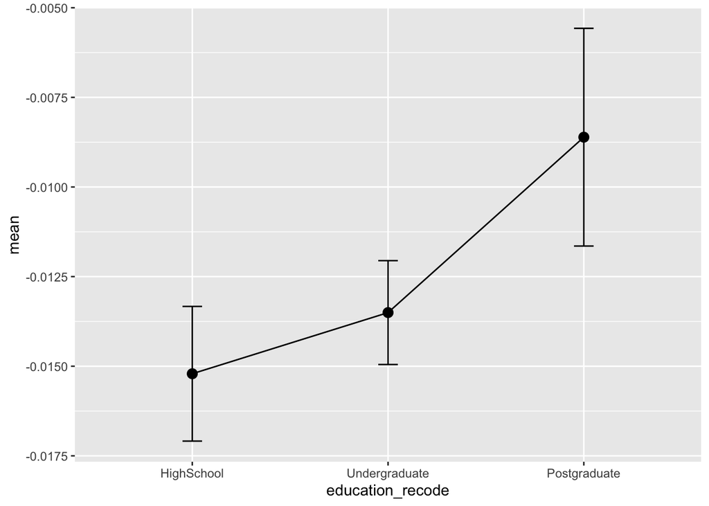

```r
# plot the means and standard errors
ggplot(education,
       aes(x = education_recode,
           y = mean,
           group = 1)) +
  geom_point(size = 3) +
  geom_line() +
  geom_errorbar(aes(ymin = mean - se,
                    ymax = mean + se),
                width = .1)
```

```r
income <- test %>%
  group_by(income_recode) %>%
  summarize(n = n(),
         mean = mean(guaussian.risk),
         sd = sd(guaussian.risk),
         se = sd / sqrt(n),
         ci = qt(0.975, df = n - 1) * sd / sqrt(n)) %>% na.omit()
knitr::kable(income)
```

| income_recode | n | mean | sd | se | ci |
| --- | --- | --- | --- | --- | --- |
| < 25,000 | 83 | -0.0144447 | 0.0207967 | 0.0022827 | 0.0045411 |
| 25,000-50,000 | 113 | -0.0126603 | 0.0176729 | 0.0016625 | 0.0032941 |
| 50,000-75,000 | 72 | -0.0114881 | 0.0166843 | 0.0019663 | 0.0039206 |
| > 75,000 | 49 | -0.0163106 | 0.0233746 | 0.0033392 | 0.0067140 |

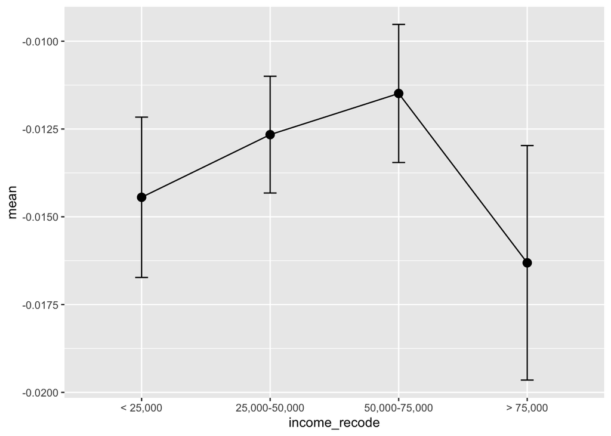

```r
# plot the means and standard errors
ggplot(income,
       aes(x = income_recode,
           y = mean,
           group = 1)) +
  geom_point(size = 3) +
  geom_line() +
  geom_errorbar(aes(ymin = mean - se,
                    ymax = mean + se),
                width = .1)
```

```r
age <- test %>%
  group_by(age_recode) %>%
  summarize(n = n(),
         mean = mean(guaussian.risk),
         sd = sd(guaussian.risk),
         se = sd / sqrt(n),
         ci = qt(0.975, df = n - 1) * sd / sqrt(n)) %>% na.omit()
knitr::kable(age)
```

| age_recode | n | mean | sd | se | ci |
| --- | --- | --- | --- | --- | --- |
| 18-24 | 22 | -0.0124271 | 0.0205834 | 0.0043884 | 0.0091262 |
| 25-49 | 246 | -0.0141303 | 0.0196952 | 0.0012557 | 0.0024734 |
| 50-75 | 51 | -0.0102133 | 0.0160193 | 0.0022432 | 0.0045055 |

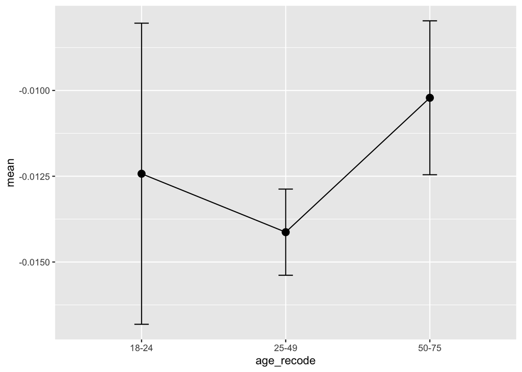

```r
# plot the means and standard errors
ggplot(age,
       aes(x = age_recode,
           y = mean,
           group = 1)) +
  geom_point(size = 3) +
  geom_line() +
  geom_errorbar(aes(ymin = mean - se,
                    ymax = mean + se),
                width = .1)
```

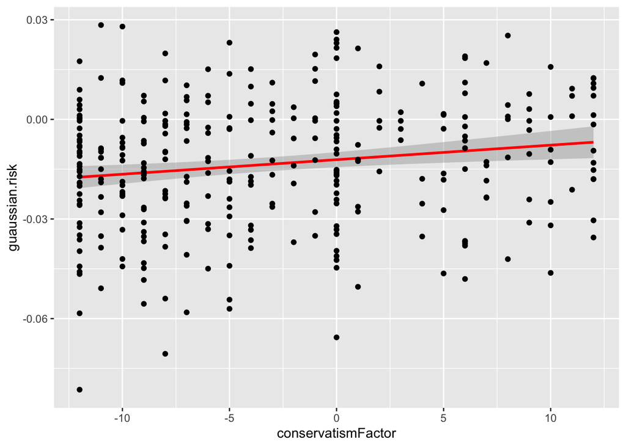

```r
ggplot(data=test, aes(x=conservatismFactor, y=guaussian.risk)) +
    geom_smooth(method = "lm", formula = y ~ x, color = "red") +
        geom_point()
```

Here are the gain plots

```r
# calculate means, standard deviations,
# standard errors, and 95% confidence
# intervals by grouping factor
education <- test %>%
  group_by(education_recode) %>%
  summarize(n = n(),
         mean = mean(guaussian.gain),
         sd = sd(guaussian.gain),
         se = sd / sqrt(n),
         ci = qt(0.975, df = n - 1) * sd / sqrt(n))
knitr::kable(education)
```

| education_recode | n | mean | sd | se | ci |
| --- | --- | --- | --- | --- | --- |
| HighSchool | 101 | 0.0184958 | 0.0190725 | 0.0018978 | 0.0037651 |
| Undergraduate | 182 | 0.0152268 | 0.0217892 | 0.0016151 | 0.0031869 |
| Postgraduate | 37 | 0.0081429 | 0.0171366 | 0.0028172 | 0.0057136 |

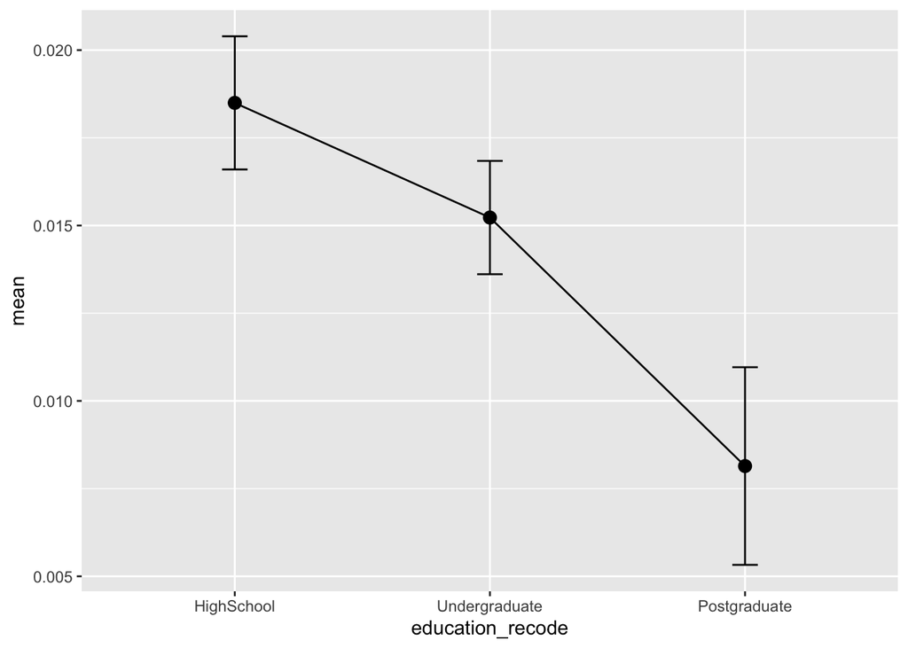

```r
# plot the means and standard errors
ggplot(education,
       aes(x = education_recode,
           y = mean,
           group = 1)) +
  geom_point(size = 3) +
  geom_line() +
  geom_errorbar(aes(ymin = mean - se,
                    ymax = mean + se),
                width = .1)
```

```r
income <- test %>%
  group_by(income_recode) %>%
  summarize(n = n(),
         mean = mean(guaussian.gain),
         sd = sd(guaussian.gain),
         se = sd / sqrt(n),
         ci = qt(0.975, df = n - 1) * sd / sqrt(n)) %>% na.omit()
knitr::kable(income)
```

| income_recode | n | mean | sd | se | ci |
| --- | --- | --- | --- | --- | --- |
| < 25,000 | 83 | 0.0160697 | 0.0208064 | 0.0022838 | 0.0045432 |
| 25,000-50,000 | 113 | 0.0153719 | 0.0202002 | 0.0019003 | 0.0037652 |
| 50,000-75,000 | 72 | 0.0153971 | 0.0195691 | 0.0023062 | 0.0045985 |
| > 75,000 | 49 | 0.0148502 | 0.0238215 | 0.0034031 | 0.0068423 |

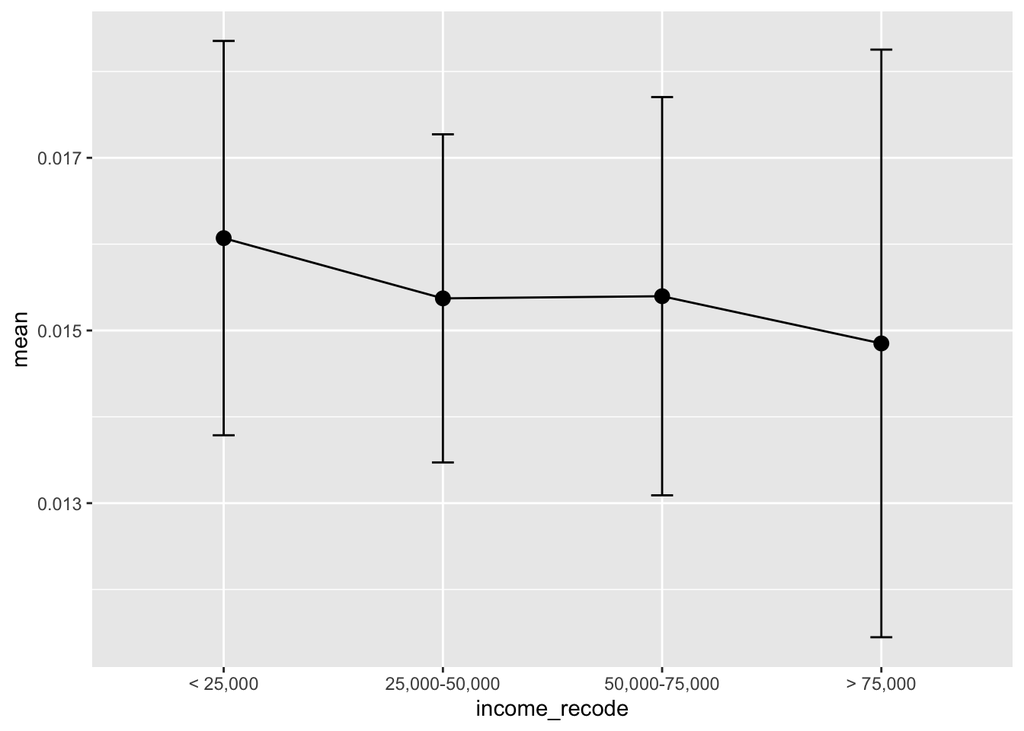

```r
# plot the means and standard errors
ggplot(income,
       aes(x = income_recode,
           y = mean,
           group = 1)) +
  geom_point(size = 3) +
  geom_line() +
  geom_errorbar(aes(ymin = mean - se,
                    ymax = mean + se),
                width = .1)
```

```r
age <- test %>%
  group_by(age_recode) %>%
  summarize(n = n(),
         mean = mean(guaussian.gain),
         sd = sd(guaussian.gain),
         se = sd / sqrt(n),
         ci = qt(0.975, df = n - 1) * sd / sqrt(n)) %>% na.omit()
knitr::kable(age)
```

| age_recode | n | mean | sd | se | ci |
| --- | --- | --- | --- | --- | --- |
| 18-24 | 22 | 0.0220850 | 0.0200193 | 0.0042681 | 0.0088761 |
| 25-49 | 246 | 0.0150012 | 0.0212218 | 0.0013531 | 0.0026651 |
| 50-75 | 51 | 0.0152039 | 0.0175101 | 0.0024519 | 0.0049248 |

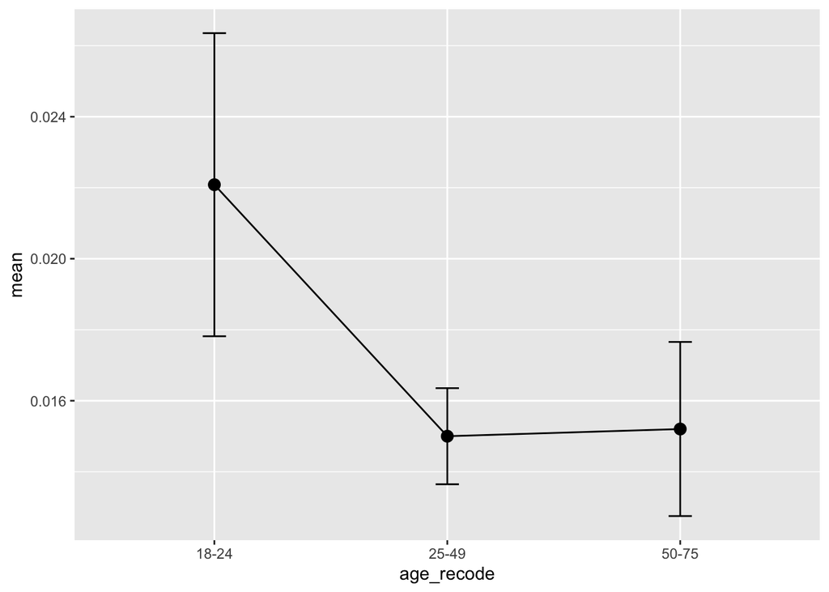

```r
# plot the means and standard errors
ggplot(age,
       aes(x = age_recode,
           y = mean,
           group = 1)) +
  geom_point(size = 3) +
  geom_line() +
  geom_errorbar(aes(ymin = mean - se,
                    ymax = mean + se),
                width = .1)
```

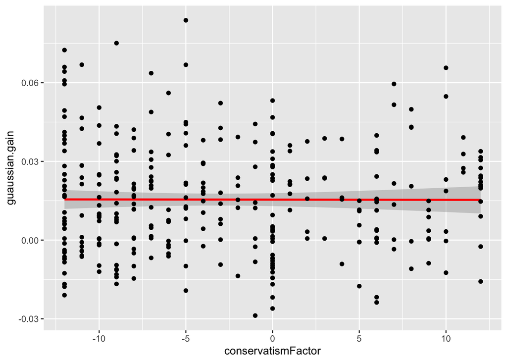

```r
ggplot(data=test, aes(x=conservatismFactor, y=guaussian.gain)) +
    geom_smooth(method = "lm", formula = y ~ x, color = "red") +
        geom_point()
```

Here are one way anovas testing differences acorss groups of age, income, and education

```r
#build the anova versions
aov.1 <- stats::oneway.test(guaussian.risk ~ age_recode, data = test, var.equal= T)
aov.2 <- stats::oneway.test(guaussian.risk ~ income_recode, data = test, var.equal= T)
aov.3 <- stats::oneway.test(guaussian.risk ~ education_recode, data = test, var.equal= T)

aov.4 <- stats::oneway.test(guaussian.gain ~ age_recode, data = test, var.equal= T)
aov.5 <- stats::oneway.test(guaussian.gain ~ income_recode, data = test, var.equal= T)
aov.6 <- stats::oneway.test(guaussian.gain ~ education_recode, data = test, var.equal= T)

tab <- map_df(list(aov.1,aov.2,aov.3, aov.4,aov.5,aov.6), tidy)
```

```
## Multiple parameters; naming those columns num.df, denom.df
## Multiple parameters; naming those columns num.df, denom.df
## Multiple parameters; naming those columns num.df, denom.df
## Multiple parameters; naming those columns num.df, denom.df
## Multiple parameters; naming those columns num.df, denom.df
## Multiple parameters; naming those columns num.df, denom.df
```

```r
knitr::kable(tab[c("num.df", "den.df", "statistic", "p.value", "method")])
```

| num.df | den.df | statistic | p.value | method |
| --- | --- | --- | --- | --- |
| 2 | 316 | 0.9064396 | 0.4050076 | One-way analysis of means |
| 3 | 313 | 0.7441946 | 0.5264141 | One-way analysis of means |
| 2 | 317 | 1.5969139 | 0.2041454 | One-way analysis of means |
| 2 | 316 | 1.2013129 | 0.3021690 | One-way analysis of means |
| 3 | 313 | 0.0385533 | 0.9898732 | One-way analysis of means |
| 2 | 317 | 3.4848605 | 0.0318377 | One-way analysis of means |

```r
########
```

Here are some plots comparing the means with standard errors of age income and education with both risk and gain on them **Note I used the inverse of Risk here**

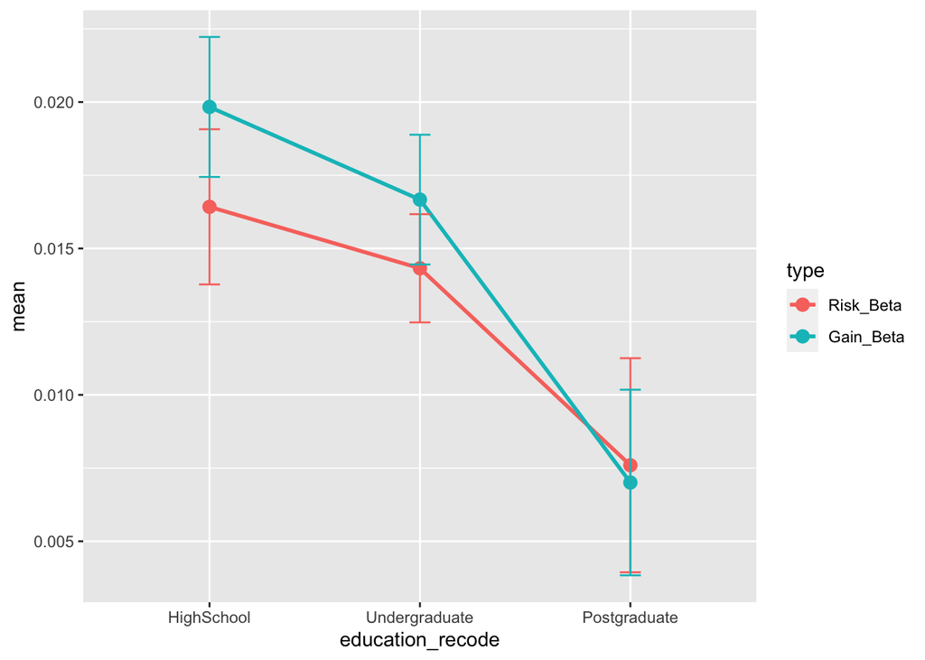

```r
test %>%
  dplyr::select(c(c("user_id", "condition", Risk_Beta, Gain_Beta, "conservatismFactor", "education_recode",
"age_recode", "income_recode"))) %>%
  mutate(Risk_Beta = -Risk_Beta) %>%
 melt(id = c("user_id",  "condition", "conservatismFactor", "education_recode",
"age_recode", "income_recode"), variable.name = "type", value.name = "beta") -> plotdata

education <- plotdata %>%
  group_by(education_recode, type) %>%
  summarize(n = n(),
            mean = mean(beta),
            sd = sd(beta),
            se = sd/sqrt(n))
# plot the means and standard errors by sex
ggplot(education, aes(x = education_recode,
                     y = mean,
                     group=type,
                     color=type)) +
  geom_point(size = 3) +
  geom_line(size = 1) +
  geom_errorbar(aes(ymin  =mean - se,
                    ymax = mean+se),
                width = .1)
```

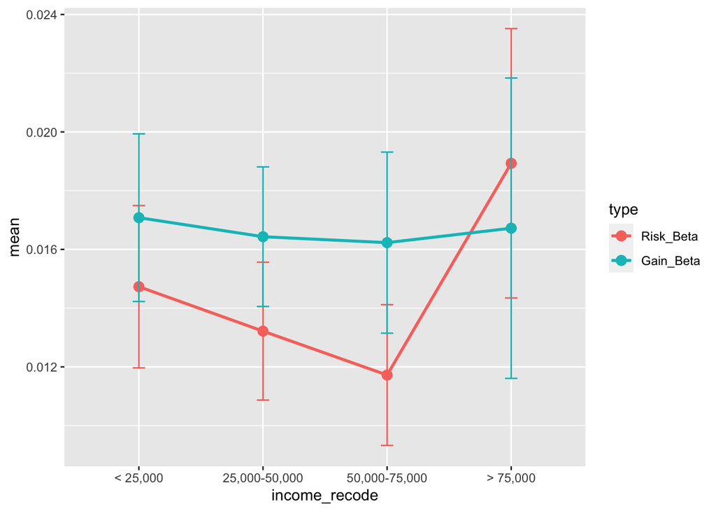

```r
income <- plotdata %>%
  group_by(income_recode, type) %>%
  summarize(n = n(),
            mean = mean(beta),
            sd = sd(beta),
            se = sd/sqrt(n))%>% na.omit()
# plot the means and standard errors by sex
ggplot(income, aes(x = income_recode,
                     y = mean,
                     group=type,
                     color=type)) +
  geom_point(size = 3) +
  geom_line(size = 1) +
  geom_errorbar(aes(ymin  =mean - se,
                    ymax = mean+se),
                width = .1)
```

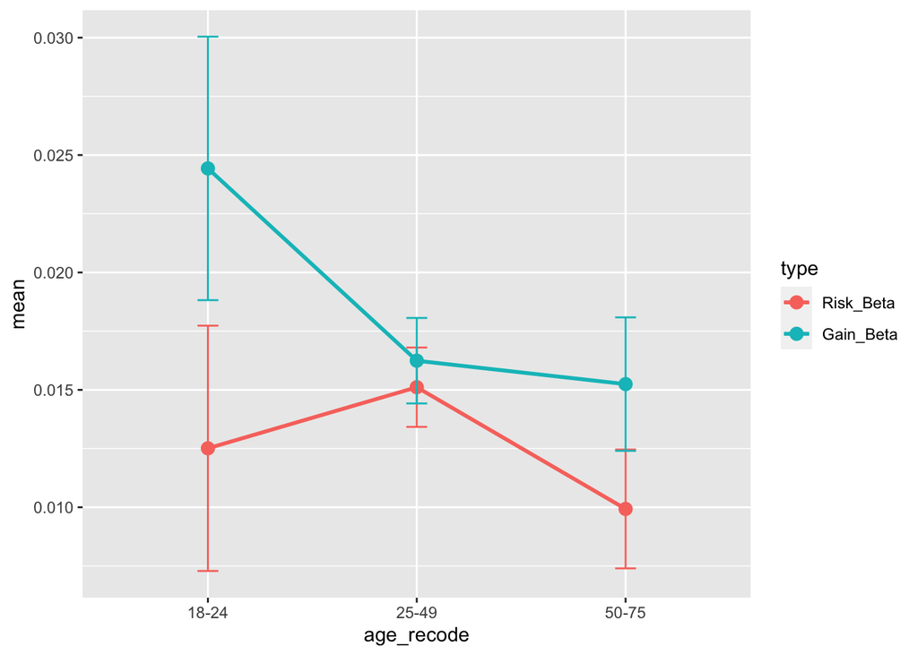

```r
age <- plotdata %>%
  group_by(age_recode, type) %>%
  summarize(n = n(),
            mean = mean(beta),
            sd = sd(beta),
            se = sd/sqrt(n)) %>% na.omit()
# plot the means and standard errors by sex
ggplot(age, aes(x = age_recode,
                     y = mean,
                     group=type,
                     color=type)) +
  geom_point(size = 3) +
  geom_line(size = 1) +
  geom_errorbar(aes(ymin  =mean - se,
                    ymax = mean+se),
                width = .1)
```